# Global Ocean Wastewater Input

Jared Kibele

April 29, 2019

We want to map how human wastewater impacts coastal oceans globally. So we’ll take world-wide country-level [sanitation data](https://github.com/jkibele/wastewater/issues/3#issuecomment-460335655), combine it with population density data to estimate human waste likely to make it into the ocean, aggregate those numbers by watershed, and map the plumes of waste as they enter the ocean. Broadly, the steps will be:

1. Develop national “sanitation factors” (sf) for each country. These values will range between 1 (representing unprocessed waste - basically just open defecation) and 0 (at least theoretically, representing a perfect sanitation system in which no human waste reaches the ocean).
2. Rasterize sf values and multiply them by population density raster to produce “effluent density”.
3. Use a vector representation of watersheds to aggregate effluent density to coastal pour points.
4. Plume modelling to represent diffusion into the coastal ocean.

This document serves as an outline of the methods used, but its primary purpose is as a guide for anyone (hopefully me) who wants to re-run or build on this analysis later.

## Datasets

The data sets used in this analysis are detailed here.

## 1) Sanitation Factors

These factors represent waste reduction. We’ll need to develop the factors, map them to geography, then rasterize the output.

#### Factor Development

These values were developed in the `sanitation_factors.Rmd`. Here they are joined to the relevant sanitation data (far right column).

| COUNTRY, AREA OR TERRITORY | ISO3 | Year | Population (thousands) | National Basic | National Limited | National Unimproved | National Open | Breakdown of Basic Safely managed | Breakdown of Basic Disposed in situ | Breakdown of Basic Emptied and treated | Breakdown of Basic Wastewater treated | Breakdown of Basic Latrines and other | Breakdown of Basic Septic tanks | Breakdown of Basic Sewer connections | sf |
| --- | --- | --- | --- | --- | --- | --- | --- | --- | --- | --- | --- | --- | --- | --- | --- |
| Afghanistan | AFG | 2015 | 32526.56 | 39.22 | 9.42 | 37.82 | 13.55 | – | – | – | – | 29.87 | 6.68 | 2.67 | 0.60 |
| Albania | ALB | 2015 | 2896.68 | 97.69 | 2.11 | 0.00 | 0.20 | 64.82 | 0.93 | 0.00 | 63.89 | 0.00 | 1.86 | 95.83 | 0.31 |
| Algeria | DZA | 2015 | 39666.52 | 87.49 | 8.42 | 3.29 | 0.80 | 19.14 | 5.87 | 0.00 | 13.28 | 3.91 | 7.83 | 75.75 | 0.34 |
| American Samoa | ASM | 2015 | 55.54 | 62.23 | 36.39 | 1.38 | 0.00 | – | – | – | – | 6.90 | 24.62 | 30.71 | 0.38 |
| Andorra | AND | 2015 | 70.47 | 100.00 | 0.00 | 0.00 | 0.00 | 100.00 | 0.00 | 0.00 | 100.00 | 0.00 | – | 100.00 | 0.30 |
| Angola | AGO | 2015 | 25021.97 | 39.43 | 14.99 | 12.74 | 32.84 | – | – | – | – | 4.53 | 28.26 | 6.64 | 0.62 |
| Anguilla | AIA | 2015 | 14.61 | 96.92 | 2.38 | 0.70 | 0.00 | – | – | – | – | 4.10 | 91.65 | 1.17 | 0.31 |
| Antigua and Barbuda | ATG | 2015 | 91.82 | 87.50 | 4.17 | 8.06 | 0.26 | – | – | – | 1.06 | 10.75 | 75.69 | 1.06 | 0.35 |
| Argentina | ARG | 2015 | 43416.75 | 94.84 | 3.28 | 0.53 | 1.35 | 26.48 | 18.94 | 0.00 | 7.54 | 10.04 | 27.84 | 56.96 | 0.32 |
| Armenia | ARM | 2015 | 3017.71 | 91.58 | 1.71 | 6.71 | 0.00 | – | – | – | – | 24.59 | 0.64 | 66.36 | 0.34 |
| Aruba | ABW | 2015 | 103.89 | 97.54 | 0.00 | 0.98 | 1.47 | – | – | – | 6.85 | 0.00 | 90.33 | 7.21 | 0.32 |
| Australia | AUS | 2015 | 23968.97 | 100.00 | 0.00 | 0.00 | 0.00 | 74.21 | 5.75 | 0.00 | 68.46 | 11.50 | – | 88.50 | 0.30 |
| Austria | AUT | 2015 | 8544.59 | 99.97 | 0.00 | 0.03 | 0.00 | 96.78 | 3.19 | 0.00 | 93.59 | 1.15 | 5.24 | 93.59 | 0.30 |
| Azerbaijan | AZE | 2015 | 9753.97 | 89.35 | 5.70 | 4.79 | 0.16 | – | – | – | 34.91 | 51.93 | 0.87 | 36.55 | 0.34 |
| Bahamas | BHS | 2015 | 388.02 | 92.01 | 4.59 | 3.40 | 0.00 | – | – | – | 9.92 | 0.61 | 79.00 | 12.40 | 0.33 |
| Bahrain | BHR | 2015 | 1377.24 | 100.00 | 0.00 | 0.00 | 0.00 | – | – | – | – | – | – | – | 0.30 |
| Bangladesh | BGD | 2015 | 160995.64 | 46.92 | 22.15 | 30.82 | 0.11 | – | – | – | – | 34.40 | 9.21 | 3.31 | 0.50 |
| Barbados | BRB | 2015 | 284.21 | 96.46 | 1.88 | 0.84 | 0.83 | – | – | – | 5.30 | 81.64 | 9.51 | 5.30 | 0.31 |
| Belarus | BLR | 2015 | 9495.83 | 94.25 | 4.87 | 0.88 | 0.00 | 76.23 | 4.81 | 0.00 | 71.42 | 4.24 | 5.38 | 84.63 | 0.31 |
| Belgium | BEL | 2015 | 11299.19 | 99.49 | 0.51 | 0.00 | 0.00 | 97.10 | 2.39 | 0.00 | 94.71 | 0.00 | 4.77 | 94.71 | 0.30 |
| Belize | BLZ | 2015 | 359.29 | 87.16 | 8.95 | 2.66 | 1.23 | – | – | – | 4.73 | 25.59 | 53.22 | 8.35 | 0.34 |
| Benin | BEN | 2015 | 10879.83 | 13.93 | 20.20 | 10.70 | 55.16 | – | – | – | – | 11.87 | 1.55 | 0.51 | 0.78 |
| Bermuda | BMU | 2015 | 62.00 | 99.90 | 0.00 | 0.10 | 0.00 | – | – | – | – | – | – | – | 0.30 |
| Bhutan | BTN | 2015 | 774.83 | 62.87 | 8.39 | 28.74 | 0.00 | – | – | – | – | 13.48 | 44.57 | 4.82 | 0.46 |
| Bolivia (Plurinational State of) | BOL | 2015 | 10724.70 | 52.61 | 20.20 | 12.69 | 14.49 | 19.01 | 8.07 | 0.00 | 10.94 | 9.48 | 6.65 | 36.48 | 0.51 |
| Bosnia and Herzegovina | BIH | 2015 | 3810.42 | 94.78 | 0.62 | 4.60 | 0.00 | 23.08 | 22.11 | 0.00 | 0.96 | 0.00 | 44.23 | 50.55 | 0.32 |
| Botswana | BWA | 2015 | 2262.49 | 59.96 | 7.92 | 15.27 | 16.86 | – | – | – | – | 55.95 | 4.01 | 0.00 | 0.51 |
| Brazil | BRA | 2015 | 207847.53 | 86.15 | 0.84 | 11.03 | 1.98 | 38.64 | 11.26 | 0.00 | 27.38 | 8.75 | 13.77 | 63.63 | 0.37 |
| British Virgin Islands | VGB | 2015 | 30.12 | 96.86 | 0.00 | 3.14 | 0.00 | – | – | – | – | 1.53 | 73.10 | 22.23 | 0.32 |
| Brunei Darussalam | BRN | 2015 | 423.19 | 96.33 | 0.00 | 1.07 | 2.60 | – | – | – | – | 1.04 | – | 95.29 | 0.32 |

[output cut: 203 more lines]

#### Mapped to Geography

After careful consideration, we decided to use the GADM and World EEZs. The vectors were combined, the $sf$ values were joined and then rasterized. The processing took place in this notebook. Here’s the raster output of $sf$ values:

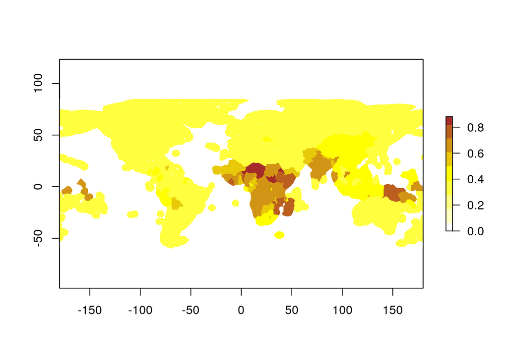

## 2) Effluent Density

The $sf$ values calculated in the previous steps were mulitplied by the population density to produce a raster of effluent density. For each cell, this results in a number assumed to be proportional to the density of nutrient/pathogen production originating within the cell. Derivation of this layer is covered in another notebook.

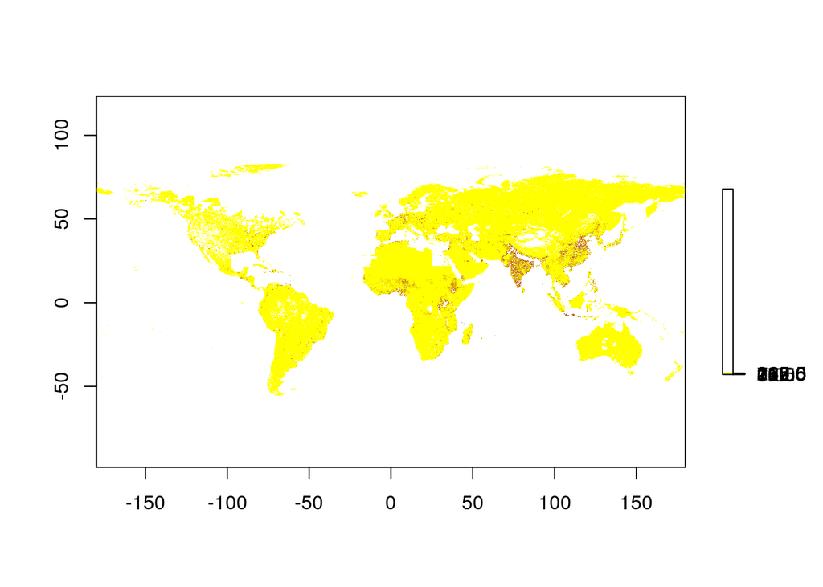

## 3) Aggregate to Pour Points

The effluent density raster was summed across watersheds. These watershed totals were then attributed to pour points representing river mouths were the watersheds enter the ocean.

Caveat: The density raster was not converted to population (dividing each cell by area) before the cells were summed. Cells near the equator would be essentially unchanged (because cells near the equator are very close to $1 km^2$), but cells closer to the poles will be a bit biased. This will be addressed in any future version of this analysis.

```python
from rasterstats import zonal_stats, gen_zonal_stats
import numpy as np
import pandas as pd
import geopandas as gpd
import rasterio
import os

data_dir = "/home/shares/ohi/git-annex/land-based/wastewater"
intermediate_dir = os.path.join(data_dir, "intermediate_files")
basins_dir = os.path.join(data_dir, "basins_laea")
shps = [os.path.join(basins_dir, fn) for fn in os.listdir(basins_dir) if fn.endswith(".shp")]
effluent_fn = os.path.join(intermediate_dir, "effluent_density.tif")
output_fn = os.path.join(intermediate_dir, "effluent_watersheds.shp")

feature_list = []
for shp_fn in shps:
    watersheds = gpd.read_file(shp_fn).to_crs(epsg=4326)
    zs_feats = zonal_stats(watersheds, effluent_fn, stats="sum count", geojson_out=True)
    feature_list.extend(zs_feats)

zgdf = gpd.GeoDataFrame.from_features(feature_list, crs=watersheds.crs)
zgdf = zgdf.rename(columns={'sum': 'effluent'})
zgdf.effluent = zgdf.effluent.fillna(0)
zgdf.to_file(output_fn)
```

Here’s a quick plot to (sort of) show how “dirty” the watersheds are. It’s a really skewed distribution, so I’ll plot $log(x+1)$. Otherwise the color scale isn’t very useful.

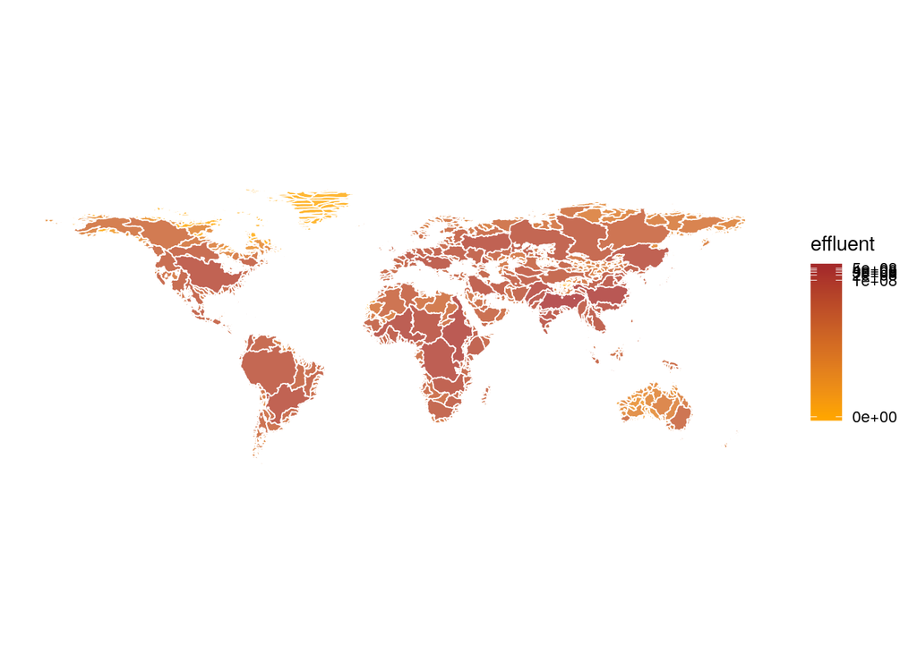

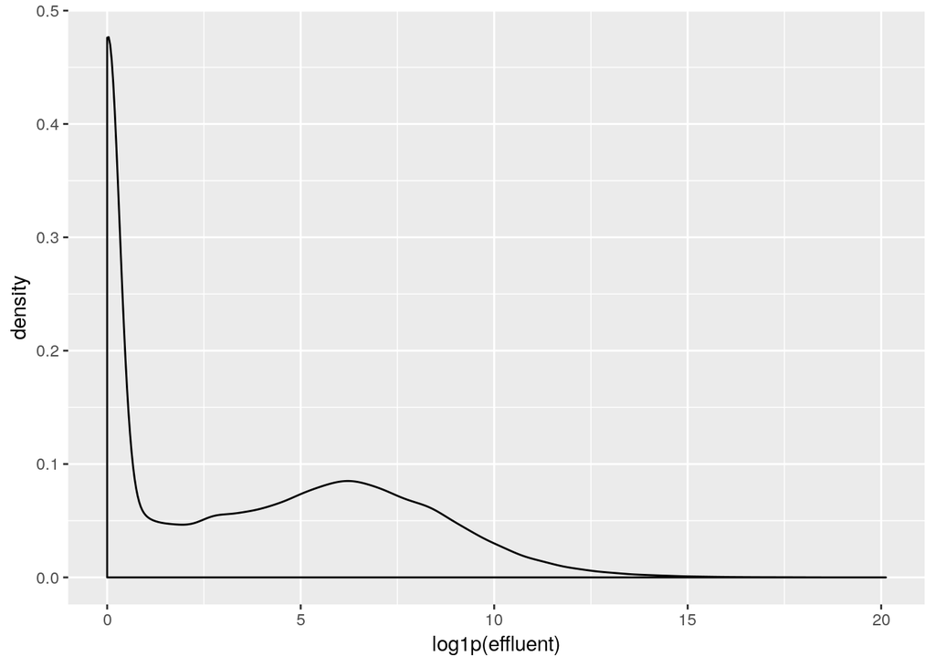

```r
ggplot(psheds, aes(log1p(effluent))) +
  geom_density()
```

#### Pour Points Mapped

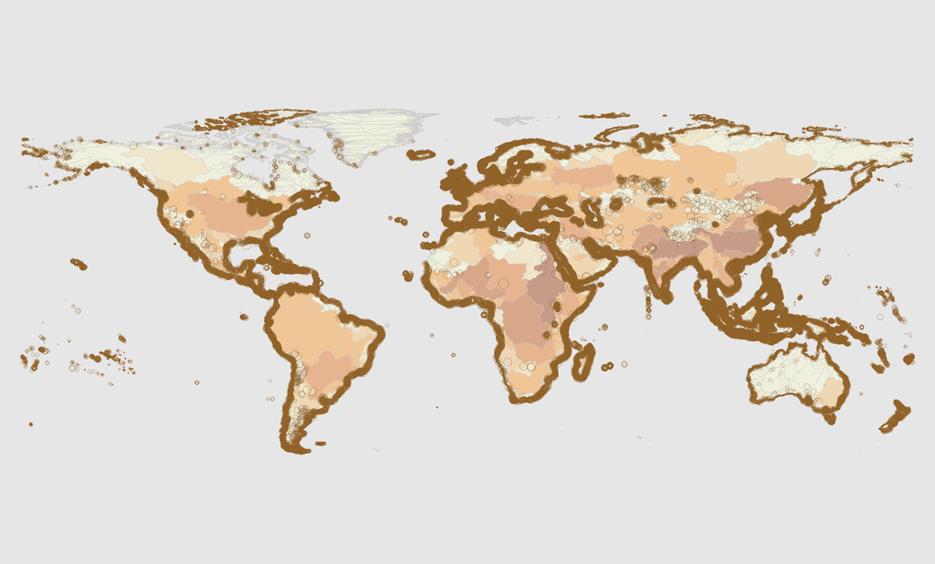

## 4) Plume Modeling and Tile Rendering

The old version of the plume model would not work in GRASS version 7.6, so that code was updated. An ocean mask was created from the GADM with 1s for ocean cells and null values for land. There was also a [tricky bug](https://github.com/jkibele/wastewater/issues/11) to be fixed. The plume model took around 10 hours or so to run.

The raw plume raster was sybolised and rendered to RGB in QGIS and turned into tiles using the QTiles QGIS plugin. The impact raster was also rendered in QGIS, but the tiles were cut using gdal2tiles because QTiles crashed repeatedly. The code to create the leaflet map is in webmap.R. Full screen web map here.

[interactive chart not shown]

## Next Steps & Potential Enhancements

For a more complete, and less tech focused list of next steps, please see the accompanying report document.

#### Gap Filling

25 Countries in GADM but not in Sanitation data

| ISO3 | name |
| --- | --- |
| XAD | Akrotiri and Dhekelia |
| ALA | Åland |
| ATA | Antarctica |
| BVT | Bouvet Island |
| IOT | British Indian Ocean Territory |
| XCA | Caspian Sea |
| CXR | Christmas Island |
| XCL | Clipperton Island |
| CCK | Cocos Islands |
| ATF | French Southern Territories |
| GGY | Guernsey |
| HMD | Heard Island and McDonald Islands |
| JEY | Jersey |
| XKO | Kosovo |
| NFK | Norfolk Island |
| XNC | Northern Cyprus |
| XPI | Paracel Islands |
| PCN | Pitcairn Islands |
| BLM | Saint-Barthélemy |
| MAF | Saint-Martin |
| SGS | South Georgia and the South Sandwich Islands |
| XSP | Spratly Islands |
| SJM | Svalbard and Jan Mayen |
| TWN | Taiwan |
| UMI | United States Minor Outlying Islands |

#### Plume Model Improvements

The current plume model describes effluent concentration as a function of distance from the pour point regardless of surface area. This means that at a given distance from a pour point, the concentration is the same regardless of whether you’re at a headland of up a narrow fjord. By incorporating both surface area and distance, we could more realistically model dispersion.

From a purely operational standpoint, the plume model could be sped up considerably. In it’s current form, it writes a huge number of intermediate raster files. This creates an IO bottleneck. So, regardless of how much RAM and how many processors are allocated, it still won’t run any faster. If re-written to reduce disk access and exploit parallel processing the code could run much, much faster. In turn, this would allow us to much more easily make small adjustments and re-run the model.